# Assignment 10 - Extra Credits: Precitive Model and Imbalanced Data

*How to do it?*:

- Open the Rmarkdown file of this assignment (link) in Rstudio.
- Right under each **question**, insert a code chunk (you can use the hotkey `Ctrl + Alt + I` to add a code chunk) and code the solution for the question.
- `Knit` the rmarkdown file (hotkey: `Ctrl + Alt + K`) to export an html.
- Publish the html file to your Githiub Page.

*Submission*: Submit the link on Github of the assignment to Canvas

1. In the `Adult Census Income` dataset ([Link](https://www.kaggle.com/uciml/adult-census-income)), identify and handle all the missing values. Put the categorical variables in factor form.

```r
library(tidyverse)
df <-read_csv("C:\\Users\\student\\Desktop\\R 421\\adult.csv")
df <- drop_na(df)
```

2. Train and test a decision tree to predict whether or not a person earns more than 50k. What is the testing accuracy of the tree? What are the three most important variables? Notice: you may need to set the positive (1) and negative (0) of the target variable.

```r
df$target <- case_when(
  df$income =="<=50K" ~ 0,
  df$income ==">50K" ~ 1,
  TRUE ~ 0)
table(df$target)
```

```
##
##     0     1
## 24720  7841
```

```r
#Creating target variable

df <- select(df,-income)
df <- select(df,-education)
#removes income category otherwise will use target as a predictor

df$target <- factor(df$target)
library(caret)
set.seed(2020)
splitIndex <- createDataPartition(df$target, p = .70,
                                  list = FALSE)
df_train <- df[ splitIndex,]
df_test <- df[-splitIndex,]

df$target <- factor(df$target)
library(rpart)
tree_model <- rpart(target ~ ., data = df_train,
                 control = rpart.control(maxdepth = 3))

library(caret)
#predict on testing data
pred <- predict(tree_model, df_test, type = "class")
#Evaluate the predictions
cm <- confusionMatrix(data = pred, reference = df_test$target, positive = "1")
treepred <-cm$overall[1]
treepred
```

```
##  Accuracy
## 0.8417281
```

```r
#84.2% accurate

library(rattle)
```

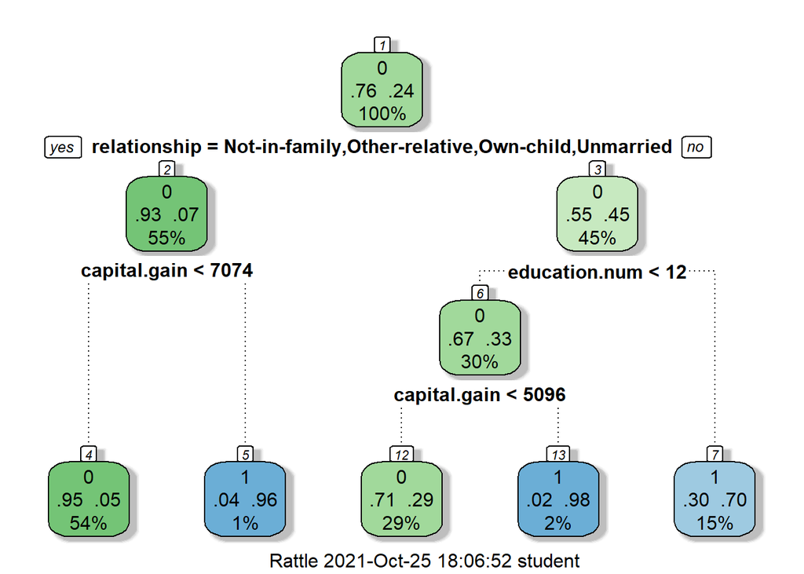

```r
fancyRpartPlot(tree_model)
```

```r
tree_model$variable.importance
```

```
##   relationship marital.status   capital.gain  education.num            sex
##    1646.314833    1620.516516     741.271559     646.805868     523.610289
##     occupation            age hours.per.week   capital.loss native.country
##     499.434536     374.075599     207.342031      15.989315      15.798966
##           race
##       2.855235
```

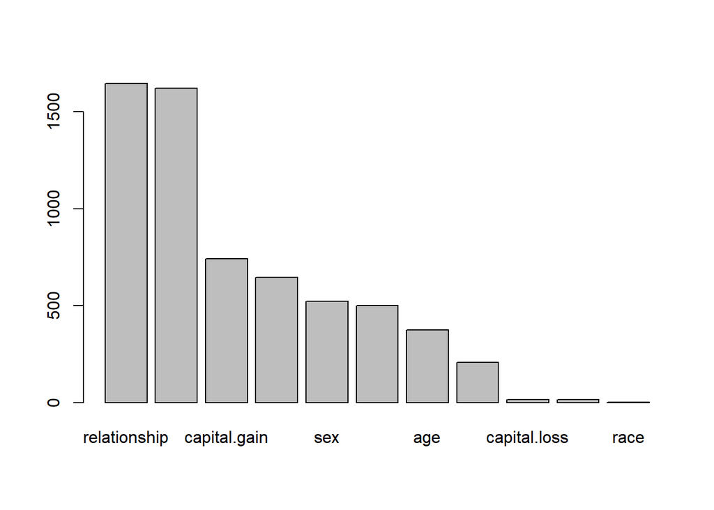

```r
#3 most important are relationship, martial.status, and capital gain
barplot(tree_model$variable.importance)
```

3. Train and test a random forest to predict whether or not a person earns more than 50k. What is the testing accuracy of the tree? What are the three most important variables?

```r
library(randomForest)
library(caret)
set.seed(2020)
splitIndex <- createDataPartition(df$target, p = .70,
                                  list = FALSE)
df_train <- df[ splitIndex,]
df_test <- df[-splitIndex,]
forest_model = randomForest(target ~ ., data=df_train, ntree = 200)

pred <- predict(forest_model, df_test, type = "class")
cm <- confusionMatrix(data = pred, reference = df_test$target, positive = "1")
cm$overall[1]
```

```
##  Accuracy
## 0.8698812
```

```r
#87% accurate, slightly better than tree model

importance(forest_model)
```

```
##                MeanDecreaseGini
## age                   872.90054
## workclass             260.65727
## fnlwgt                821.57338
## education.num         923.10357
## marital.status        564.12946
## occupation            449.47570
## relationship          814.22396
## race                   94.93558
## sex                   107.03534
## capital.gain         1004.42999
## capital.loss          270.24432
## hours.per.week        555.53487
## native.country        122.95202
```

```r
#3 most important are capital.gain, education.num, and age
```

4. Download credit card default data at [this link](https://www.kaggle.com/uciml/default-of-credit-card-clients-dataset). Train and test a random forest to predict whether or not a customer has a default payment next month. What is the accuracy of the forest?

```r
library(tidyverse)
df2 <-read_csv("C:\\Users\\student\\Desktop\\R 421\\UCI_Credit_Card.csv")

names(df2)[25] <- 'target'
#Naming target variable
df2$target <- factor(df2$target)

library(randomForest)
library(caret)
set.seed(2020)
splitIndex <- createDataPartition(df2$target, p = .70,
                                  list = FALSE)
df2_train <- df2[ splitIndex,]
df2_test <- df2[-splitIndex,]
forest_model2 = randomForest(target ~ ., data=df2_train, ntree = 200)

pred2 <- predict(forest_model2, df2_test, type = "class")
cm2 <- confusionMatrix(data = pred2, reference = df2_test$target, positive = "1")
cm2$overall[1]
```

```
## Accuracy
## 0.816424
```

5. Sometime, the accuracy is not enough to evaluate a model. In this example, we notice that the model predicts the `not-default payment` very well which reflects through the high specificity (True Negative Rate), but predicts the `default payment` not very well reflecting through a low sensitivity (True Positive Rate). The balanced accuracy is the average of the sensitivity and specificity. Use `cm$byClass[11]` to check the these metrics of the model.

```r
cm2$byClass[1]
```

```
## Sensitivity
##   0.3487437
```

```r
cm2$byClass[2]
```

```
## Specificity
##   0.9492082
```

```r
cm2$byClass[11]
```

```
## Balanced Accuracy
##         0.6489759
```

```r
prop.table(table(df2$target))
```

```
##
##      0      1
## 0.7788 0.2212
```

7. (Challenging) We want to improve the sensitivity of the model. To do that we first need to balance the training data so that there is a 50:50 distribution between the two classes (default and not default). Do the follows to balance the training data
   - Split the original training data into 2 subsets. Subset 1 contains default customers. Subset 2 contains the remainders. Let n1, and n2 be the numbers of the rows in Subset 1 and 2 respectively.

```r
library('tidyverse')
dfDEFAULT <- filter(df2, target == "1")
dfGOOD <- filter(df2, target =="0")
length(dfDEFAULT$target)
```

```
## [1] 6636
```

```r
#6636 defaults
length(dfGOOD$target)
```

```
## [1] 23364
```

```r
#23364 customers who don't default
```

- Create a new training data contains Subset 1 and randomly n1 observations in Subset 2. You can use the `sample` functions to randomly select n1 observations in Subset 2. You can use the `rbind` function to merge two dataset by row.

```r
dfGOODpart <- sample_n(dfGOOD,6636)
dfNEW <-rbind(dfDEFAULT,dfGOODpart)
prop.table(table(dfNEW$target))
```

```
##
##   0   1
## 0.5 0.5
```

- Train a random forest on the new training data. Calculate the specificity and balanced accuracy of the new model on the (same) testing data.

```r
library(randomForest)
library(caret)
set.seed(2020)
splitIndex <- createDataPartition(dfNEW$target, p = .70,
                                  list = FALSE)
dfNEW_train <- dfNEW[ splitIndex,]
dfNEW_test <- dfNEW[-splitIndex,]
forest_modelNEW = randomForest(target ~ ., data=dfNEW_train, ntree = 200)

predNEW <- predict(forest_modelNEW, dfNEW_test, type = "class")
cmNEW <- confusionMatrix(data = predNEW, reference = dfNEW_test$target, positive = "1")
cmNEW$overall[1]
```

```
##  Accuracy
## 0.6967337
```

```r
#Accuracy lower than 81.6% earlier
```

```r
cmNEW$byClass[1]
```

```
## Sensitivity
##   0.6437186
```

```r
#Sensitivity up from 34.9% earlier
cmNEW$byClass[2]
```

```
## Specificity
##   0.7497487
```

```r
cmNEW$byClass[11]
```

```
## Balanced Accuracy
##         0.6967337
```

```r
#Balanced Accuracy higher than 64.9% earlier
```